# Linear Regression (선형회귀)

- 회귀
  - 회귀: '다시 본디 상태로 되돌아 온다'는 뜻
  - 영국의 유전학자 갈톤 (F. Galton, 1822 ~ 1891)에 의해서 회귀라는 용어가 등장
    - 그의 유전에 관한 논문 'Family Likeness in Stature (1886)'에서 처음 회귀에 대하여 정의함
      - 일반적으로 키가 큰 부모에게서 키 큰 자녀가, 키가 작은 부모에게서 키 작은 자녀가 태어난다. 그렇지만 자녀들의 평균 키는 전체 인구의 평균 키로 회귀하는 경향이 있다.
      - 즉, 키가 큰 부모이든 작은 부모이든 그들에게서 태어난 자녀들의 평균 키는 전체 평균 키 수준에 접근하는 현상으로 나타난다
      - 이러한 현상을 '보편적 회귀법칙 (law of universal regression)' 이라 한다.
  - 보편적 회귀법칙은 피어슨 (K. Pearson, 1857 ~ 1936) 에 의해서 체계적인 회귀분석 이론으로 정립되었음
    - 피어슨은, 1,078 개 가족 구성원 자료를 수집하여 아버지 키와 아들 키 사이에 존재하는 회귀법칙을 규명하였다.
    - 피어슨의 회귀법칙 결론
      - 아버지 키가 비교적 큰 집단에서 태어난 아들들의 평균 키는 그 아버지 평균 키보다는 작다.
      - 아버지 키가 비교적 작은 집단에서 태어난 아들들의 평균 키는 그 아버지 평균 키보다 크다.
      - 따라서 아들의 키는 전체 평균 키 수준을 향하여 회귀하는 현상을 나타냄.
- 변수의 종류
  - 결과 변수 (Outcome variable): 반응 변수 (Response Variable), 종속 변수 (Dependent Variable), 분류명 (Classified Name)
  - 예측 변수 (Predictor): 설명 변수 (Explanatory Variable), 독립 변수 (Independent Variable), 특징 (Feature)
- 회귀분석
  - 한 종속변수가 하나 이상의 독립변수에 의해 어떠한 영향을 받고 또한 어떠한 관계로 나타나는지 분석하는 기법
  - 결과 변수의 값을 다른 예측 변수들로 부터 설명하고 예측하는 것
- 회귀분석의 종류
  - 선형회귀 (Linear Regression)
    - 여러 개의 예측 변수와 하나의 결과 변수 사이에 선형 관계 (Linear Relationship)가 존재한다는 가정하에 그러한 변수 사이의 선형 구조를 *모형화* 하는 것
  - 비선형회귀 (Nonlinear Regression)
    - 종속변수와 독립변수 간의 임의적 관계로서 모형화

  ```
  ~~~~~~~~~~~~~~~~~~~~~~~~~~~~~~~~~~~~~~~~~~~~~~~~~~~~~~~~
   [선형 관계 (Linear Relationship)]

   예측 변수 X1에 대해서 결과 변수 Y1이 결정되고, 예측 변수 X2에 대해서는 결과 변수 Y2가 결정된다고 할 때,
   aX1 + bX2에 대해서는 결과 변수가 aY1 + bY2가 될 때 예측 변수와 결과 변수 사이에는 선형 관계가 있다고 말한다.

   더 간단히 한줄로 설명하면.
   "예측 변수와 결과 변수에 대해서, 예측 변수 X1, X2, ... 각각의 결과 변수를 안다면, 모든 가능한 X1, X2, ... 들의 조합에 대해서도 결과 변수를 예측 할 수 있다."

   만약 위와 같은 조건이 맞지 않는다면 예측 변수와 결과 변수는 비선형 관계가 된다.
  ~~~~~~~~~~~~~~~~~~~~~~~~~~~~~~~~~~~~~~~~~~~~~~~~~~~~~~~~
  ```

- 회귀 분석 선형 모형
  - 회귀 분석 알고리즘 및 훈련 데이터를 통하여 임의의 예측 함수 h를 생성
  - 예측 함수 h를 hypothesis 라고 부름
  - 예측 함수 h에 새로운 예측 변수를 넣으면 결과 변수를 출력함 (결과를 예측함)
- 수학적 정의
  - $n$개의 속성($n$개의 예측 변수)을 지닌 훈련 데이터 $n$-벡터 $X_i=\{x_{i1}, x_{i2}, ..., x_{in}\}$가 총 $m$ (즉, $1 \le i \le m$)개 주어지고,
  - 각 $X_i$ 벡터마다 연관된 실수 값 $y_i$ (결과 변수)이 주어질 때,
  - 임의의 $n$-벡터 $X =\{x_1, x_2,...,x_n\}$에 대해 $$ $$ $$h_{\theta}(X) = \theta_0 + \theta_1 x_1 + \theta_2 x_2 + ... + \theta_n x_n$$ $$$$
  - 위 식에서 $\theta=\{\theta_0, \theta_1, \theta_2, ..., \theta_n\}$는 계수 벡터(Coefficient Vector)라고 부른다.
- 계수 벡터 $\theta$를 구하는 수학적 모델
  - 주어진 통계적 수치(훈련 데이터)들에 대해 다음 비용 함수 (Cost Function) $J(\theta)$를 구한다. $$ $$ $$J(\theta) = \dfrac{1}{2m} \sum_{i=1}^m \big| h_\theta(X_i) - y_i \big|^2$$ $$$$
  - 비용 함수 $J(\theta)$를 Square Error Function 이라고도 칭함
  - 비용 함수 $J(\theta)$를 최소로 만드는 $\theta$ 벡터가 선형 모델에서 찾으려고 하는 것임
- 비용 함수 $J(\theta)$를 최소로 만드는 $\theta$ 벡터를 구하는 방법
  - Gradient Descent
    - http://dev-strender.github.io/machine%20learning/2015/03/22/ML-Stanford1/
  - Normal Equation

## 1. Univariate Linear Regression (단일 변수 선형 회귀분석)

- $m$개의 통계치 $x_i$ (즉, $1 \le i \le m$)와 이와 연관된 실수 값 $y_i$에 대하여
- 새로운 통계 수치 $x$와 연관된 실수 값 $y$를 예측하기 위해 다음과 같은 모형을 고려함 $$$$ $$h_{\theta_0, \theta_1}(x) = \theta_0 + \theta_1 \cdot x$$ $$$$
- 최적의 h 함수를 위한 $\theta_0$와 $\theta_1$을 구하기 위하여 다음 비용 함수 $J(\theta_0, \theta_1)$를 고려 $$$$ $$J(\theta_0, \theta_1) = \dfrac{1}{2m}\sum_{i=1}^m \big| \theta_0 + \theta_1\cdot x_i - y_i \big|^2$$ $$$$

### 1) 필요한 모듈을 지역 이름 공간에 불러오기

```python
from scipy import stats
from pandas import Series, DataFrame
import pandas as pd
import matplotlib.pyplot as plt
import numpy as np
import scipy
%matplotlib inline
```

### 2) 통계 수치 데이터 정의 및 Pandas를 활용한 데이터프레임 정의

- 최고 기온과 에어콘 판매 대수 데이터 (다소 극단적인 예)

```python
data = {
    'Temperature': [26, 27, 28, 29, 30, 31, 32, 33],
    'Number of Sells': [270, 280, 290, 300, 310, 320, 330, 340]
}
df = pd.DataFrame(data)
```

```python
df
```

|  | Number of Sells | Temperature |
| --- | --- | --- |
| 0 | 270 | 26 |
| 1 | 280 | 27 |
| 2 | 290 | 28 |
| 3 | 300 | 29 |
| 4 | 310 | 30 |
| 5 | 320 | 31 |
| 6 | 330 | 32 |
| 7 | 340 | 33 |

```python
df['Temperature'].values
```

```
array([26, 27, 28, 29, 30, 31, 32, 33])
```

```python
df['Number of Sells'].values
```

```
array([270, 280, 290, 300, 310, 320, 330, 340])
```

### 3) 통계 수치에 대한 Scatter Plot 생성

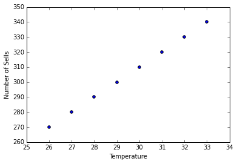

```python
df.plot(kind="scatter", x="Temperature", y="Number of Sells")
```

### 4) scipy 모듈을 활용한 선형 회귀 분석

```python
slope, intercept, r_value, p_value, std_err = stats.linregress(df['Temperature'].values, df['Number of Sells'].values)
```

```python
format = "%40s: %12.10f"
print format % ("slope", slope)
print format % ("intercept", intercept)
print format % ("r_value (Correlation Coefficient)", r_value)
print format % ("r-squared (Coefficient of Determination)", r_value**2)
print format % ("p_value (Hyperthesis Testing)", p_value)
print format % ("std_err (Standard Error)", std_err)
```

```
                                   slope: 10.0000000000
                               intercept: 10.0000000000
       r_value (Correlation Coefficient): 1.0000000000
r-squared (Coefficient of Determination): 1.0000000000
           p_value (Hyperthesis Testing): 0.0000000000
                std_err (Standard Error): 0.0000000000
```

### 5) 선형 회귀식 및 예측

- 회귀식: $y = intercept + slope \times x$
  - 위 예제의 회귀식: $y = 10.0 + 10.0 \times x$
- 질문: 온도가 34일 때 예상 에어콘 판매량은? $10 + 10 \times 34 = 350$

### 6) 상관 계수 (correlation coefficient)

- r-value (Pearson correlation coefficient): $$ r-value = \frac{cov(x_i, y_i)}{\sigma_{x_i} \sigma_{y_i}}$$

  where
  - $cov(x_i,y_i)$ is the covariance of $x_i$ and $y_i$
    - corvariance: https://goo.gl/ryS1dO
  - $\sigma_{x_i}$ and $\sigma_{y_i}$ are the standard deviation of $x_i$ and $y_i$, respectively.
- r-value의 의미
  - $x_i$ 값들과 $y_i$ 값들 사이의 관계
    - 1: 강한 양의 상관 관계
    - 0: 아무 관계 없음
    - -1: 강한 음의 상관 관계
  - 참고: https://en.wikipedia.org/wiki/Pearson_product-moment_correlation_coefficient
- [참고] Covariance 구하는 Python 코딩

```python
def cov(a, b):

    if len(a) != len(b):
        return

    a_mean = np.mean(a)
    b_mean = np.mean(b)

    sum = 0

    for i in range(0, len(a)):
        sum += ((a[i] - a_mean) * (b[i] - b_mean))

    return sum/(len(a) - 1)
```

- 위 코드에서 마지막 라인에 1을 빼는 이유
  - 자유도 (Degree of Feeedom): http://math7.tistory.com/113
- numpy를 활용한 r-value (상관 계수) 구하기

```python
a = np.cov(df['Temperature'].values, df['Number of Sells'].values, ddof = 1)[0][1]
print a
b = np.std(df['Temperature'].values, ddof = 1)
print b
c = np.std(df['Number of Sells'].values, ddof = 1)
print c
print a / (b * c)
```

```
60.0
2.44948974278
24.4948974278
1.0
```

- numpy를 이용한 r-value (상관 계수) 구하기

```python
np.corrcoef(df['Temperature'].values, df['Number of Sells'].values, ddof = 1)[0][1]
```

```
1.0
```

### 7) 결정 계수 (Coefficient of Determination)

- r-squared: 추정된 회귀선이 표본 자료에 적합한가를 측정하는 결정 계수
- 0 에서 1 사이에 값을 갖는다
  - r-squared이 0에 가까울 때: 두 변수 X와 Y 사이에는 관계가 거의 없으며 회귀분석을 적용함에 적합치 않다는 의미
  - r-squared이 1에 가까울 때: 두 변수 X와 Y 사이에는 매우 강한 관계가 있으며 회귀분석 적용이 적합함을 의미
    - r-squared가 1이라는 것은 두 변수 X와 Y가 확정적(Deterministic) 관계이며 그 관계성에 오차가 없으므로 회귀분석을 적용할 이유가 없다.

### 8) 가설 검증 (Hyperthesis Testing)과 p-value (유의 확률)

- 다음의 두 가지 가설을 세울 수 있음
  - **Null Hyperthesis** (귀무 가설): 예측 변수(Predictor)와 결과 변수(Outcome Variable)사이에 아무런 관계가 없다.
  - **Alternative Hypothesis** (대립 가설): 예측 변수(Predictor)와 결과 변수(Outcome Variable)사이에 (선형)관계가 존재한다.
- p-value (유의 확률): **Null Hyperthesis**가 만족할 확률
- 통계학적으로, **p-value < 0.05** 이면 **Null Hyperthesis**가 만족할 확률은 거의 없다고 간주하고 **Alternative Hyperthesis**를 받아들인다.
  - 참고: http://www.editage.co.kr/edm-nw-v6.html

### 9) 표준 오차 (Standard Error)

- 표준 오차 (std_err): 통계치 ($x_i$, $y_i$)들과 선형 회귀 모델사이의 평균 거리
- 표준 오차가 적을 수록 그러한 통계치가 선형 회귀 모델식에 가깝게 분포

## 2. Simple Linear Regression - II (실제 통계 데이터를 활용한 선형 회귀분석)

### 1) 데이터 설명

- URL
  - https://raw.githubusercontent.com/bluebibi/LINK_ML_BIG_DATA/master/death_rate.csv
- D: 사망률
- A1 ~ A15: 사망률에 영향이 있을 것 같은 각종 요인 데이터
- References
  - Richard Gunst and Robert Mason, Regression Analysis and Its Applications: a data-oriented approach, Dekker, 1980, pages 370-371
  - Gary McDonald and Richard Schwing, Instabilities of regression estimates relating air pollution to mortality, Technometrics, Volume 15, Number 3, pages 463-482, 1973.
  - Helmut Spaeth, Mathematical Algorithms for Linear Regression, Academic Press, 1991, ISBN 0-12-656460-4.
- The death rate is to be represented as a function of other variables.
- There are 60 rows of data. The data includes:
  - I: the index;
  - A1: the average annual precipitation (강수량);
  - A2: the average January temperature;
  - A3: the average July temperature;
  - A4: the size of the population older than 65;
  - A5: the number of members per household;
  - A6: the number of years of schooling for persons over 22;
  - A7: the number of households with fully equipped kitchens;
  - A8: the population per square mile;
  - A9: the size of the nonwhite population;
  - A10: the number of office workers;
  - A11: the number of families with an income less than $3000;
  - A12: the hydrocarbon pollution index;
  - A13: the nitric oxide pollution index;
  - A14: the sulfur dioxide pollution index;
  - A15: the degree of atmospheric moisture.
  - D: the death rate.

### 2) Pandas를 활용한 데이터프레임 정의

```python
import urllib2
import json

path = 'https://raw.githubusercontent.com/bluebibi/LINK_ML_BIG_DATA/master/death_rate.csv'
raw_csv = urllib2.urlopen(path)
df = pd.read_csv(raw_csv)
```

```python
df
```

|  | I | A1 | A2 | A3 | A4 | A5 | A6 | A7 | A8 | A9 | A10 | A11 | A12 | A13 | A14 | A15 | D |
| --- | --- | --- | --- | --- | --- | --- | --- | --- | --- | --- | --- | --- | --- | --- | --- | --- | --- |
| 0 | 1 | 36 | 27 | 71 | 8.1 | 3.34 | 11.4 | 81.5 | 3243 | 8.8 | 42.6 | 11.7 | 21 | 15 | 59 | 59 | 0.921 |
| 1 | 2 | 35 | 23 | 72 | 11.1 | 3.14 | 11.0 | 78.8 | 4281 | 3.6 | 50.7 | 14.4 | 8 | 10 | 39 | 57 | 0.997 |
| 2 | 3 | 44 | 29 | 74 | 10.4 | 3.21 | 9.8 | 81.6 | 4260 | 0.8 | 39.4 | 12.4 | 6 | 6 | 33 | 54 | 0.962 |
| 3 | 4 | 47 | 45 | 79 | 6.5 | 3.41 | 11.1 | 77.5 | 3125 | 27.1 | 50.2 | 20.6 | 18 | 8 | 24 | 56 | 0.982 |
| 4 | 5 | 43 | 35 | 77 | 7.6 | 3.44 | 9.6 | 84.6 | 6441 | 24.4 | 43.7 | 14.3 | 43 | 38 | 206 | 55 | 1.071 |
| 5 | 6 | 53 | 45 | 80 | 7.7 | 3.45 | 10.2 | 66.8 | 3325 | 38.5 | 43.1 | 25.5 | 30 | 32 | 72 | 54 | 1.030 |
| 6 | 7 | 43 | 30 | 74 | 10.9 | 3.23 | 12.1 | 83.9 | 4679 | 3.5 | 49.2 | 11.3 | 21 | 32 | 62 | 56 | 0.934 |
| 7 | 8 | 45 | 30 | 73 | 9.3 | 3.29 | 10.6 | 86.0 | 2140 | 5.3 | 40.4 | 10.5 | 6 | 4 | 4 | 56 | 0.899 |
| 8 | 9 | 36 | 24 | 70 | 9.0 | 3.31 | 10.5 | 83.2 | 6582 | 8.1 | 42.5 | 12.6 | 18 | 12 | 37 | 61 | 1.001 |
| 9 | 10 | 36 | 27 | 72 | 9.5 | 3.36 | 10.7 | 79.3 | 4213 | 6.7 | 41.0 | 13.2 | 12 | 7 | 20 | 59 | 0.912 |
| 10 | 11 | 52 | 42 | 79 | 7.7 | 3.39 | 9.6 | 69.2 | 2302 | 22.2 | 41.3 | 24.2 | 18 | 8 | 27 | 56 | 1.017 |
| 11 | 12 | 33 | 26 | 76 | 8.6 | 3.20 | 10.9 | 83.4 | 6122 | 16.3 | 44.9 | 10.7 | 88 | 63 | 278 | 58 | 1.024 |
| 12 | 13 | 40 | 34 | 77 | 9.2 | 3.21 | 10.2 | 77.0 | 4101 | 13.0 | 45.7 | 15.1 | 26 | 26 | 146 | 57 | 0.970 |
| 13 | 14 | 35 | 28 | 71 | 8.8 | 3.29 | 11.1 | 86.3 | 3042 | 14.7 | 44.6 | 11.4 | 31 | 21 | 64 | 60 | 0.985 |
| 14 | 15 | 37 | 31 | 75 | 8.0 | 3.26 | 11.9 | 78.4 | 4259 | 13.1 | 49.6 | 13.9 | 23 | 9 | 15 | 58 | 0.958 |
| 15 | 16 | 35 | 46 | 85 | 7.1 | 3.22 | 11.8 | 79.9 | 1441 | 14.8 | 51.2 | 16.1 | 1 | 1 | 1 | 54 | 0.860 |
| 16 | 17 | 36 | 30 | 75 | 7.5 | 3.35 | 11.4 | 81.9 | 4029 | 12.4 | 44.0 | 12.0 | 6 | 4 | 16 | 58 | 0.936 |
| 17 | 18 | 15 | 30 | 73 | 8.2 | 3.15 | 12.2 | 84.2 | 4824 | 4.7 | 53.1 | 12.7 | 17 | 8 | 28 | 38 | 0.871 |
| 18 | 19 | 31 | 27 | 74 | 7.2 | 3.44 | 10.8 | 87.0 | 4834 | 15.8 | 43.5 | 13.6 | 52 | 35 | 124 | 59 | 0.959 |
| 19 | 20 | 30 | 24 | 72 | 6.5 | 3.53 | 10.8 | 79.5 | 3694 | 13.1 | 33.8 | 12.4 | 11 | 4 | 11 | 61 | 0.941 |
| 20 | 21 | 31 | 45 | 85 | 7.3 | 3.22 | 11.4 | 80.7 | 1844 | 11.5 | 48.1 | 18.5 | 1 | 1 | 1 | 53 | 0.891 |
| 21 | 22 | 31 | 24 | 72 | 9.0 | 3.37 | 10.9 | 82.8 | 3226 | 5.1 | 45.2 | 12.3 | 5 | 3 | 10 | 61 | 0.871 |
| 22 | 23 | 42 | 40 | 77 | 6.1 | 3.45 | 10.4 | 71.8 | 2269 | 22.7 | 41.4 | 19.5 | 8 | 3 | 5 | 53 | 0.971 |
| 23 | 24 | 43 | 27 | 72 | 9.0 | 3.25 | 11.5 | 87.1 | 2909 | 7.2 | 51.6 | 9.5 | 7 | 3 | 10 | 56 | 0.887 |
| 24 | 25 | 46 | 55 | 84 | 5.6 | 3.35 | 11.4 | 79.7 | 2647 | 21.0 | 46.9 | 17.9 | 6 | 5 | 1 | 59 | 0.952 |
| 25 | 26 | 39 | 29 | 76 | 8.7 | 3.23 | 11.4 | 78.6 | 4412 | 15.6 | 46.6 | 13.2 | 13 | 7 | 33 | 60 | 0.968 |
| 26 | 27 | 35 | 31 | 81 | 9.2 | 3.10 | 12.0 | 78.3 | 3262 | 12.6 | 48.6 | 13.9 | 7 | 4 | 4 | 55 | 0.919 |
| 27 | 28 | 43 | 32 | 74 | 10.1 | 3.38 | 9.5 | 79.2 | 3214 | 2.9 | 43.7 | 12.0 | 11 | 7 | 32 | 54 | 0.844 |
| 28 | 29 | 11 | 53 | 68 | 9.2 | 2.99 | 12.1 | 90.6 | 4700 | 7.8 | 48.9 | 12.3 | 648 | 319 | 130 | 47 | 0.861 |
| 29 | 30 | 30 | 35 | 71 | 8.3 | 3.37 | 9.9 | 77.4 | 4474 | 13.1 | 42.6 | 17.7 | 38 | 37 | 193 | 57 | 0.989 |
| 30 | 31 | 50 | 42 | 82 | 7.3 | 3.49 | 10.4 | 72.5 | 3497 | 36.7 | 43.3 | 26.4 | 15 | 10 | 34 | 59 | 1.006 |
| 31 | 32 | 60 | 67 | 82 | 10.0 | 2.98 | 11.5 | 88.6 | 4657 | 13.6 | 47.3 | 22.4 | 3 | 1 | 1 | 60 | 0.861 |
| 32 | 33 | 30 | 20 | 69 | 8.8 | 3.26 | 11.1 | 85.4 | 2934 | 5.8 | 44.0 | 9.4 | 33 | 23 | 125 | 64 | 0.929 |
| 33 | 34 | 25 | 12 | 73 | 9.2 | 3.28 | 12.1 | 83.1 | 2095 | 2.0 | 51.9 | 9.8 | 20 | 11 | 26 | 50 | 0.857 |
| 34 | 35 | 45 | 40 | 80 | 8.3 | 3.32 | 10.1 | 70.3 | 2682 | 21.0 | 46.1 | 24.1 | 17 | 14 | 78 | 56 | 0.961 |
| 35 | 36 | 46 | 30 | 72 | 10.2 | 3.16 | 11.3 | 83.2 | 3327 | 8.8 | 45.3 | 12.2 | 4 | 3 | 8 | 58 | 0.923 |
| 36 | 37 | 54 | 54 | 81 | 7.4 | 3.36 | 9.7 | 72.8 | 3172 | 31.4 | 45.5 | 24.2 | 20 | 17 | 1 | 62 | 1.113 |
| 37 | 38 | 42 | 33 | 77 | 9.7 | 3.03 | 10.7 | 83.5 | 7462 | 11.3 | 48.7 | 12.4 | 41 | 26 | 108 | 58 | 0.994 |
| 38 | 39 | 42 | 32 | 76 | 9.1 | 3.32 | 10.5 | 87.5 | 6092 | 17.5 | 45.3 | 13.2 | 29 | 32 | 161 | 54 | 1.015 |
| 39 | 40 | 36 | 29 | 72 | 9.5 | 3.32 | 10.6 | 77.6 | 3437 | 8.1 | 45.5 | 13.8 | 45 | 59 | 263 | 56 | 0.991 |
| 40 | 41 | 37 | 38 | 67 | 11.3 | 2.99 | 12.0 | 81.5 | 3387 | 3.6 | 50.3 | 13.5 | 56 | 21 | 44 | 73 | 0.893 |
| 41 | 42 | 42 | 29 | 72 | 10.7 | 3.19 | 10.1 | 79.5 | 3508 | 2.2 | 38.3 | 15.7 | 6 | 4 | 18 | 56 | 0.938 |
| 42 | 43 | 41 | 33 | 77 | 11.2 | 3.08 | 9.6 | 79.9 | 4843 | 2.7 | 38.6 | 14.1 | 11 | 11 | 89 | 54 | 0.946 |
| 43 | 44 | 44 | 39 | 78 | 8.2 | 3.32 | 11.0 | 79.9 | 3768 | 28.6 | 49.5 | 17.5 | 12 | 9 | 48 | 53 | 1.025 |
| 44 | 45 | 32 | 25 | 72 | 10.9 | 3.21 | 11.1 | 82.5 | 4355 | 5.0 | 46.4 | 10.8 | 7 | 4 | 18 | 60 | 0.874 |
| 45 | 46 | 34 | 32 | 79 | 9.3 | 3.23 | 9.7 | 76.8 | 5160 | 17.2 | 45.1 | 15.3 | 31 | 15 | 68 | 57 | 0.953 |
| 46 | 47 | 10 | 55 | 70 | 7.3 | 3.11 | 12.1 | 88.9 | 3033 | 5.9 | 51.0 | 14.0 | 144 | 66 | 20 | 61 | 0.839 |
| 47 | 48 | 18 | 48 | 63 | 9.2 | 2.92 | 12.2 | 87.7 | 4253 | 13.7 | 51.2 | 12.0 | 311 | 171 | 86 | 71 | 0.911 |
| 48 | 49 | 13 | 49 | 68 | 7.0 | 3.36 | 12.2 | 90.7 | 2702 | 3.0 | 51.9 | 9.7 | 105 | 32 | 3 | 71 | 0.790 |
| 49 | 50 | 35 | 40 | 64 | 9.6 | 3.02 | 12.2 | 82.5 | 3626 | 5.7 | 54.3 | 10.1 | 20 | 7 | 20 | 72 | 0.899 |
| 50 | 51 | 45 | 28 | 74 | 10.6 | 3.21 | 11.1 | 82.6 | 1883 | 3.4 | 41.9 | 12.3 | 5 | 4 | 20 | 56 | 0.904 |
| 51 | 52 | 38 | 24 | 72 | 9.8 | 3.34 | 11.4 | 78.0 | 4923 | 3.8 | 50.5 | 11.1 | 8 | 5 | 25 | 61 | 0.950 |
| 52 | 53 | 31 | 26 | 73 | 9.3 | 3.22 | 10.7 | 81.3 | 3249 | 9.5 | 43.9 | 13.6 | 11 | 7 | 25 | 59 | 0.972 |
| 53 | 54 | 40 | 23 | 71 | 11.3 | 3.28 | 10.3 | 73.8 | 1671 | 2.5 | 47.4 | 13.5 | 5 | 2 | 11 | 60 | 0.912 |
| 54 | 55 | 41 | 37 | 78 | 6.2 | 3.25 | 12.3 | 89.5 | 5308 | 25.9 | 59.7 | 10.3 | 65 | 28 | 102 | 52 | 0.967 |
| 55 | 56 | 28 | 32 | 81 | 7.0 | 3.27 | 12.1 | 81.0 | 3665 | 7.5 | 51.6 | 13.2 | 4 | 2 | 1 | 54 | 0.823 |
| 56 | 57 | 45 | 33 | 76 | 7.7 | 3.39 | 11.3 | 82.2 | 3152 | 12.1 | 47.3 | 10.9 | 14 | 11 | 42 | 56 | 1.003 |
| 57 | 58 | 45 | 24 | 70 | 11.8 | 3.25 | 11.1 | 79.8 | 3678 | 1.0 | 44.8 | 14.0 | 7 | 3 | 8 | 56 | 0.895 |
| 58 | 59 | 42 | 83 | 76 | 9.7 | 3.22 | 9.0 | 76.2 | 9699 | 4.8 | 42.2 | 14.5 | 8 | 8 | 49 | 54 | 0.911 |
| 59 | 60 | 38 | 28 | 72 | 8.9 | 3.48 | 10.7 | 79.8 | 3451 | 11.7 | 37.5 | 13.0 | 14 | 13 | 39 | 58 | 0.954 |

### 3) 회귀 분석을 위한 몇가지 요인 선택

- A1 (연강수량)
- A2 (1월 온도)
- A3 (7월 온도)

```python
df_sub = df[['A1','A2','A3', 'D']]
```

```python
df_sub.head()
```

|  | A1 | A2 | A3 | D |
| --- | --- | --- | --- | --- |
| 0 | 36 | 27 | 71 | 0.921 |
| 1 | 35 | 23 | 72 | 0.997 |
| 2 | 44 | 29 | 74 | 0.962 |
| 3 | 47 | 45 | 79 | 0.982 |
| 4 | 43 | 35 | 77 | 1.071 |

### 4) 통계 수치에 대한 Scatter Plot 생성

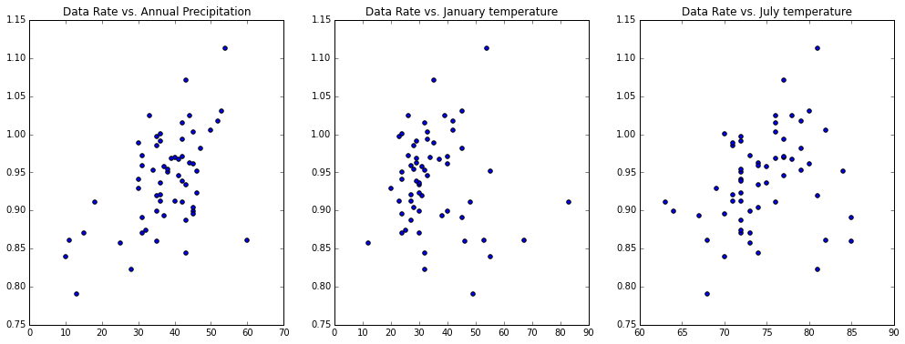

```python
fig = plt.figure(figsize=(17, 6))
ax1 = fig.add_subplot(131)
ax1.scatter(df_sub['A1'], df_sub['D'])
ax1.set_title("Data Rate vs. Annual Precipitation")

ax2 = fig.add_subplot(132)
ax2.scatter(df_sub['A2'], df_sub['D'])
ax2.set_title("Data Rate vs. January temperature")

ax3 = fig.add_subplot(133)
ax3.scatter(df_sub['A3'], df_sub['D'])
ax3.set_title("Data Rate vs. July temperature")
```

### 5) scipy 모듈을 활용한 선형 회귀 분석

```python
slope, intercept, r_value, p_value, std_err = stats.linregress(df_sub['A1'].values, df_sub['D'].values)
```

```python
format = "%40s: %12.10f"
print format % ("slope", slope)
print format % ("intercept", intercept)
print format % ("r_value (Correlation Coefficient)", r_value)
print format % ("r-squared (Coefficient of Determination)", r_value**2)
print format % ("p_value (Hyperthesis Testing)", p_value)
print format % ("std_err (Standard Error)", std_err)
```

```
                                   slope: 0.0031827857
                               intercept: 0.8209365741
       r_value (Correlation Coefficient): 0.5105898154
r-squared (Coefficient of Determination): 0.2607019596
           p_value (Hyperthesis Testing): 0.0000307229
                std_err (Standard Error): 0.0007037705
```

- 모든 Predicator 변수들에 대한 분석

```python
predicator_analysis = {}
for i in range(1, 16):
    predicator_analysis[i] = Series(np.empty(6), index=['slope', 'intercept', 'r_value', 'r_squared', 'p_value', 'std_err'])
    predicator_analysis[i][0],\
    predicator_analysis[i][1],\
    predicator_analysis[i][2],\
    predicator_analysis[i][4],\
    predicator_analysis[i][5] = stats.linregress(df['A' + str(i)].values, df['D'].values)
    predicator_analysis[i][3] = predicator_analysis[i][2] ** 2


format1 = "%3s %15s %15s %15s %15s %15s %15s"
format2 = "%3d %15f %15f %15f %15f %15f %15f"
print format1 % ('No.', 'slope', 'intercept', 'r_value', 'r_squared', 'p_value', 'std_err')
for i in range(1, 16):
    lst = [i]
    for j in range(6):
        lst.append(predicator_analysis[i][j])
    print format2 % tuple(lst)

df2 = pd.DataFrame(predicator_analysis)
print df2
```

```
No.           slope       intercept         r_value       r_squared         p_value         std_err
  1        0.003183        0.820937        0.510590        0.260702        0.000031        0.000704
  2       -0.000303        0.950407       -0.058248        0.003393        0.658436        0.000681
  3        0.003644        0.668059        0.279026        0.077856        0.030855        0.001647
  4       -0.007426        1.005207       -0.174749        0.030537        0.181736        0.005494
  5        0.165038        0.401320        0.358641        0.128623        0.004895        0.056404
  6       -0.037738        1.353973       -0.512525        0.262681        0.000028        0.008302
  7       -0.005178        1.358817       -0.427713        0.182938        0.000653        0.001437
  8        0.000011        0.896037        0.264186        0.069794        0.041378        0.000005
  9        0.004495        0.886501        0.644138        0.414914        0.000000        0.000701
 10       -0.003838        1.116685       -0.285295        0.081393        0.027137        0.001693
 11        0.006153        0.851430        0.411251        0.169127        0.001098        0.001791
 12       -0.000121        0.944433       -0.178268        0.031780        0.172960        0.000087
 13       -0.000109        0.942326       -0.081369        0.006621        0.536543        0.000176
 14        0.000418        0.917388        0.425798        0.181304        0.000694        0.000117
 15       -0.000617        0.975347       -0.054101        0.002927        0.681404        0.001495
                 1         2         3         4         5         6   \
slope      0.003183 -0.000303  0.003644 -0.007426  0.165038 -0.037738
intercept  0.820937  0.950407  0.668059  1.005207  0.401320  1.353973
r_value    0.510590 -0.058248  0.279026 -0.174749  0.358641 -0.512525
r_squared  0.260702  0.003393  0.077856  0.030537  0.128623  0.262681
p_value    0.000031  0.658436  0.030855  0.181736  0.004895  0.000028
std_err    0.000704  0.000681  0.001647  0.005494  0.056404  0.008302

                 7         8             9         10        11        12  \
slope     -0.005178  0.000011  4.494578e-03 -0.003838  0.006153 -0.000121
intercept  1.358817  0.896037  8.865010e-01  1.116685  0.851430  0.944433
r_value   -0.427713  0.264186  6.441380e-01 -0.285295  0.411251 -0.178268
r_squared  0.182938  0.069794  4.149138e-01  0.081393  0.169127  0.031780
p_value    0.000653  0.041378  2.812330e-08  0.027137  0.001098  0.172960
std_err    0.001437  0.000005  7.008191e-04  0.001693  0.001791  0.000087

                 13        14        15
slope     -0.000109  0.000418 -0.000617
intercept  0.942326  0.917388  0.975347
r_value   -0.081369  0.425798 -0.054101
r_squared  0.006621  0.181304  0.002927
p_value    0.536543  0.000694  0.681404
std_err    0.000176  0.000117  0.001495
```

### 6) 선형 회귀식 및 예측

- 연간 강수량 (A1)과 사망률간의 관계: $y = 0.82 + 0.003 * x$
  - 강수량이 70일 때 사망률은? $0.82 + 0.003 * 70 = 1.03$

### 7) 선형 회귀식과 Scatter Plot을 함께 생성

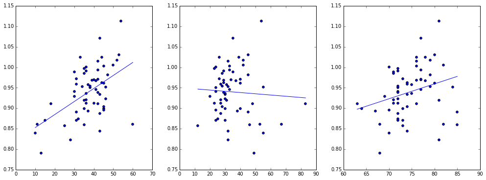

```python
fig = plt.figure(figsize=(17, 6))
ax1 = fig.add_subplot(131)
ax1.scatter(df_sub['A1'], df_sub['D'])
line_plot_x1 = np.linspace(df_sub['A1'].min(), df_sub['A1'].max(), 10)
slope, intercept, r_value, p_value, std_err = stats.linregress(df_sub['A1'].values, df_sub['D'].values)
ax1.plot(line_plot_x1, intercept + slope * line_plot_x1)

ax2 = fig.add_subplot(132)
ax2.scatter(df_sub['A2'], df_sub['D'])
line_plot_x2 = np.linspace(df_sub['A2'].min(), df_sub['A2'].max(), 10)
slope, intercept, r_value, p_value, std_err = stats.linregress(df_sub['A2'].values, df_sub['D'].values)
ax2.plot(line_plot_x2, intercept + slope * line_plot_x2)

ax3 = fig.add_subplot(133)
ax3.scatter(df_sub['A3'], df_sub['D'])
line_plot_x3 = np.linspace(df_sub['A3'].min(), df_sub['A3'].max(), 10)
slope, intercept, r_value, p_value, std_err = stats.linregress(df_sub['A3'].values, df_sub['D'].values)
ax3.plot(line_plot_x3, intercept + slope * line_plot_x3)
```

## 3. Multivariate Linear Regression (다변수 선형 회귀분석)

### - sklearn 모듈을 활용한 다중 변수 선형 회귀

```python
from sklearn import linear_model
regr = linear_model.LinearRegression()
```

### 1) A1과 A6에 대한 사망률 변화

```python
df[['A1', 'A6']].head()
```

|  | A1 | A6 |
| --- | --- | --- |
| 0 | 36 | 11.4 |
| 1 | 35 | 11.0 |
| 2 | 44 | 9.8 |
| 3 | 47 | 11.1 |
| 4 | 43 | 9.6 |

```python
X = zip(df['A1'], df['A6'])
print X
y = df['D'].values
```

```
[(36, 11.4), (35, 11.0), (44, 9.8000000000000007), (47, 11.1), (43, 9.5999999999999996), (53, 10.199999999999999), (43, 12.1), (45, 10.6), (36, 10.5), (36, 10.699999999999999), (52, 9.5999999999999996), (33, 10.9), (40, 10.199999999999999), (35, 11.1), (37, 11.9), (35, 11.800000000000001), (36, 11.4…
```

```python
regr = regr.fit(X, y)

print 'Coefficients:', regr.coef_
print 'Intercept:', regr.intercept_
```

```
Coefficients: [ 0.0021277  -0.02541196]
Intercept: 1.13921548096
```

### 2) 선형 회귀식 및 예측

- 선형 회귀식: $y = 1.1392 + 0.0021 * A1 - 0.0254 * A6$

```python
test_x = [36, 12]
print regr.predict(test_x)
print 1.1392 + 0.0021 * 36 - 0.0254 * 12
```

[output not shown]

### 3) Scatter Plot 및 선형 회귀 Plane 생성

```python
# Plot outputs
from mpl_toolkits.mplot3d import Axes3D
fig = plt.figure(figsize=(17, 7))
ax1 = fig.add_subplot(121, projection='3d')
ax1.scatter(df['A1'], df['A6'], df_sub['D'])

ax2 = fig.add_subplot(122, projection='3d')
ax2.scatter(df['A1'], df['A6'], df_sub['D'])
# create x,y
xx, yy = np.meshgrid(range(int(df['A1'].min()), int(df['A1'].max())), range(int(df['A6'].min()), int(df['A6'].max())))
# calculate corresponding z
z = 1.1392 + 0.0021 * xx - 0.0254 * yy
ax2.plot_surface(xx, yy, z, rstride=1, cstride=1, linewidth=0, color="yellow", shade=False)
```

[output not shown]

## 4. Refererence

- http://scikit-learn.org/stable/modules/linear_model.html
- http://radimrehurek.com/data_science_python/
- http://nbviewer.ipython.org/github/justmarkham/DAT4/blob/master/notebooks/08_linear_regression.ipynb